# 9 - Case study

In this chapter, we will be looking at the `gapminder` dataset from the `dslabs` package.

We aim to use graphs to answer the following questions:

1. For many years, the western world (Western Europe and North America) is characterized by long life spans and small families; whereas, the developing world (Africa, Asia, and Latin America) is characterized by short life spans and large families. Do the data support this view?
2. Has wealth distribution across the world become worse over the years?

## 1 Life spans and family sizes

### a. Life expectancy v.s. fertility in 1960

We will start with looking at the the relationship between life expectancy and fertility in 1960. Make an appropriate plot color-coded by the continent.

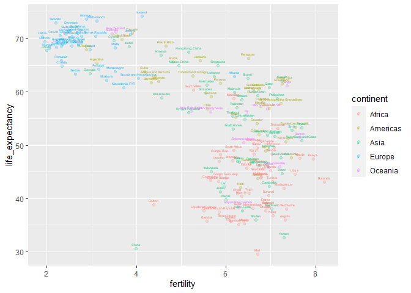

```r
gapminder |>
  filter(year == 1960) |>
  ggplot(aes(x = fertility, y = life_expectancy, label = country, color = continent)) + # label is a var so PUT IN AES
  geom_point(alpha=.2) + #transparency of text
  geom_text(size = 1.25, vjust =-1) # add countries name - need label
```

### b. 1960 -> 1980 -> 2010

In 1960, “the West versus developing world” view was grounded in some reality. Is this still the case 20 years later? 50 years later?

Make a panel of plots that show the relationship between life expectancy and fertility in 1960, 1980, and 2010.Separate the plot by both year and continent.

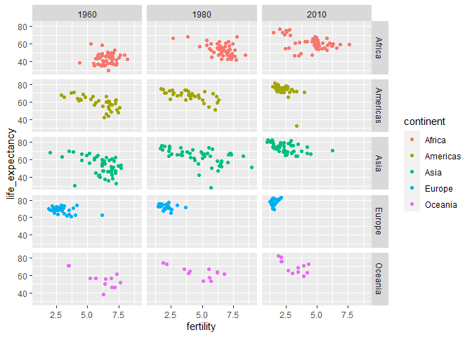

```r
gapminder |>
  filter(year %in% c(1960,1980,2010)) |>
  ggplot(aes(x = fertility, y = life_expectancy, color = continent)) +
  geom_point() +
  facet_grid(continent~year)
```

### c. West v.s. Developing

Instead of comparing across 5 continents, we will create a variable `group` as following to categorize “the West versus developing world”:

```r
gapminder <- gapminder %>%
  mutate(group = case_when(
    region %in% c("Northern America", "Northern Europe", "Australia and New Zealand", "Western Europe","Southern Europe") ~ "West",
    region %in% c("Caribbean", "South America", "Central America") ~ "Latin America",
    region %in% c("Eastern Asia", "South-Eastern Asia") ~ "East Asia",
    continent == "Africa" & region != "Northern Africa" ~ "Sub-Saharan",
    .default = "Others"))
```

Make a panel of plots that show the relationship between life expectancy and fertility in 1960, 1980, and 2010. Separate by both year and group.

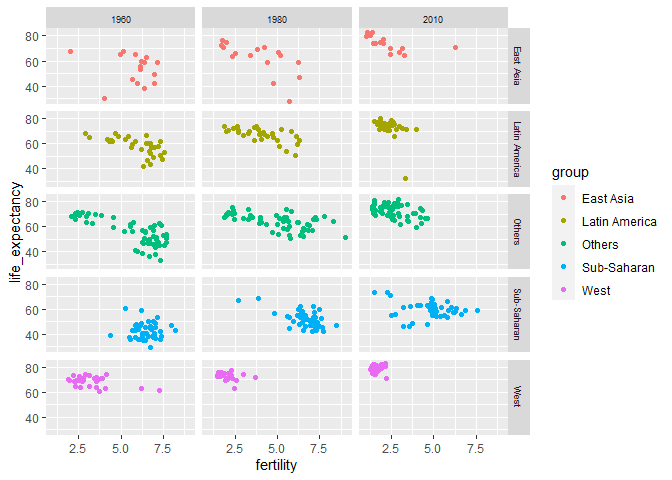

```r
gapminder |>
  filter(year %in% c(1960,1980,2010)) |>
  ggplot(aes(x = fertility, y = life_expectancy, color = group)) +
  geom_point() +
  facet_grid(group~year)+
  theme(strip.text = element_text(
  size = 7))
```

## 2 GDP

The GDP measures the market value of goods and services produced by a country in a year. The GDP per capita is often used as a rough summary of a country’s wealth. The World Bank has a daily per capita international poverty line (IPL), a global absolute minimum, of $2.15 a day as of September 2022.

First, create a variable called `daily_per_capita` that is taking the country’s gpd divided by its’ population and then divided by 365 days. Round to 2 decimals.

```r
gapminder <- gapminder |> # ASSIGN to save
  mutate(daily_per_capita = round((gdp/population)/365,2))
```

### a. Daily_per_capita in 1960

Make a histogram to see the distribution of the daily_per_capita in 1960. Adjust the scale of the x-axis to be started from 0 with an increment of 2.5.

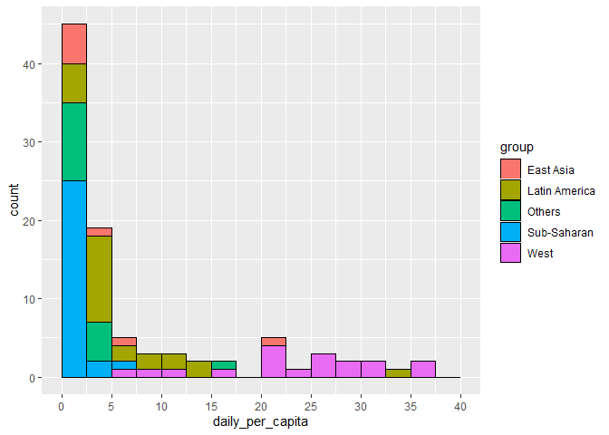

```r
gapminder |>
  filter(year == 1960 & !is.na(daily_per_capita)) |> # filter N/As
  ggplot(aes(x = daily_per_capita, fill = group)) +
  geom_histogram(breaks=seq(0,40,2.5), color = "black") +
  scale_x_continuous(breaks=seq(0,40,5))
```

### b. Daily_per_capita in each country in 1960

The above histogram showed us that the 1960 income distribution values show a dichotomy. However, the histogram does not show us if the two groups of countries are west versus the developing world.

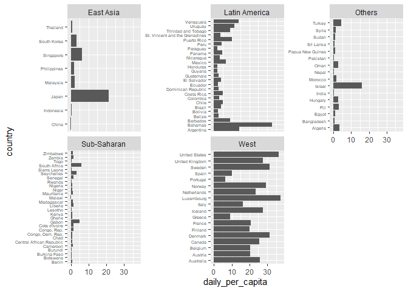

```r
gapminder |>
  filter(year == 1960 & !is.na(daily_per_capita)) |> # filter N/As
  ggplot(aes(x=daily_per_capita, y=country)) +
  geom_col()+
  facet_wrap(~group, scales = "free_y") +
  theme(axis.text.y = element_text(size = 5.25))
```

### c. Daily_per_capita in 1960 in each group

It is still a bit difficult to see the differences between Western and Developing countries. Let’s quickly examine the daily_per_capita by the group variable we created previously.

Make a panel of boxplots for daily_per_capita in 1960 in each group. Reorder the boxplots by the median daily_per_capita.

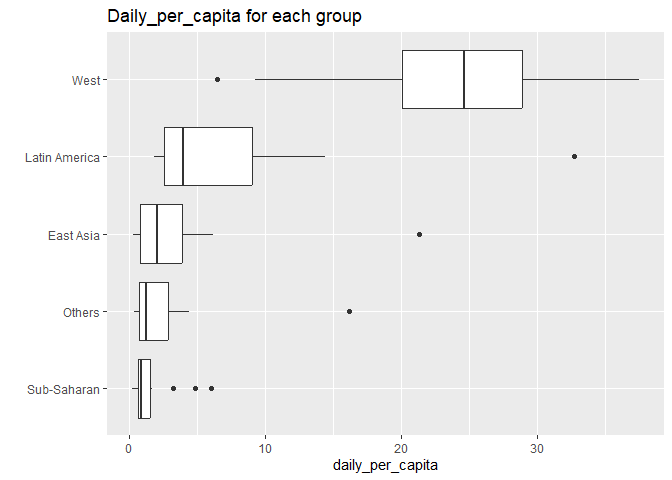

```r
gapminder |>
  filter(year == 1960 & !is.na(daily_per_capita)) |> # filter N/As
  ggplot(aes(x=daily_per_capita, y=reorder(group, daily_per_capita, median))) +
  geom_boxplot() +
  labs(y ="", title = "Daily_per_capita for each group")
```

### d. Daily_per_capita from 1960 -> 1980 -> 2010 in each region

Make a panel of boxplots for daily_per_capita in 1960, 1980, and 2010. Reorder the boxplots by the median daily_per_capita. Adjust the labels and titles as you see fit. Color-code by group.

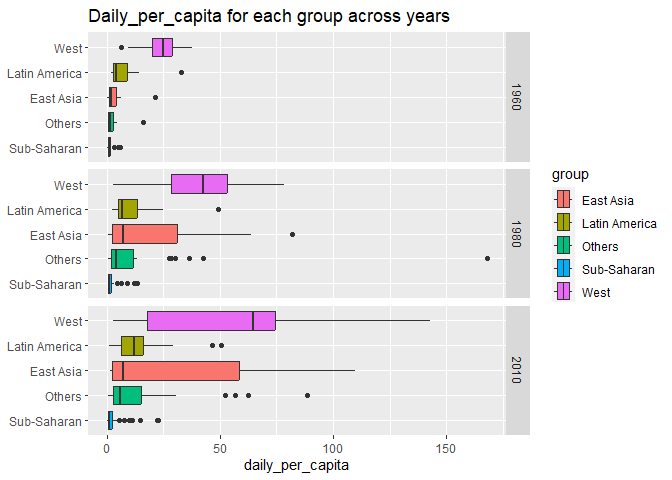

```r
gapminder |>
  filter(year %in% c(1960, 1980, 2010) & !is.na(daily_per_capita)) |> # filter N/As
  ggplot(aes(x=daily_per_capita, y = reorder(group, daily_per_capita, median), fill = group)) +
  geom_boxplot() +
  facet_grid(year~.) +labs(title = "Daily_per_capita for each group across years",
    y = NULL)
```